# DLM-Sensor

November 8, 2017

## Dynamic Linear Model

Dynamic linear models are special cases of state space model where distributions are assumed to be Gaussian. \[ y_t = F_t \theta_t + \nu_t, \quad \nu_t \sim N_m(0, V_t) \\ \theta_t = G_t \theta_{t-1} + \omega_t, \quad \omega_t \sim N_p(0, W_t) \] The model is completed by specifying a prior: \[ \theta_0 \sim N(m_0, C_0) \]

## Sensor data

- In DLM, \(y_t\) and \(\theta_t\) are \(m\) and \(p\) dimensional random vectors, respectively.
- \(y_t\) observed data, \(\theta_t\) latent, unobserved state.
- \(F_t\), \(G_t\), \(V_t\) and \(W_t\)are real matrices of the appropriate dimensions.
- We can take \(y_t\) as observed data (sensor, gcode etc.) and \(\theta_t\) as the true position of the robot.
- We want to learn \(\theta_t\).

## Random Walk plus noise model

- A simple model is the random walk plus noise model where \(F_t\), \(G_t\), \(V_t\) and \(W_t\) do not depend on time.

\[ y_t = \theta_t + \nu_t, \quad \nu_t \sim N_m(0, V_t) \\ \theta_t = \theta_{t-1} + \omega_t, \quad \omega_t \sim N_p(0, W_t) \]

## Local Linear Trend

\[ y_t = \mu_t + \nu_t, \quad \nu_t \sim N_m(0, V_t) \\ \mu_t = \mu_{t-1} + \delta_{t-1} + \omega_t^{\mu}, \quad \omega_t^{\mu} \sim N(0, W^{\mu}) \\ \delta_t = \delta_{t-1} + \omega_t^{\delta}, \quad \omega_t^{\delta} \sim N(0, W^{\delta}) \]

- This model is used to describes dynamic of straight line observed with noise.
- levels \(\mu_t\) which are locally linear function of time.
- straight line if \(W^{\mu}\) and \(W^{\delta}\) are equal to 0.
- This might be an useful model. Look at the plot !

## Another way

\[ y_t = \mu_t + \nu_t, \quad \nu_t \sim N_m(0, V_t) \\ \Delta \mu_t = \delta_{t-1} + \omega_t^{\mu}, \quad \omega_t^{\mu} \sim N(0, W^{\mu}) \\ \Delta \delta_t = \omega_t^{\delta}, \quad \omega_t^{\delta} \sim N(0, W^{\delta}) \] - \(y_t\) : sensor measurement, \(\mu_t\): g-code. - \(\delta_t\): true position. - \(V_t\): measurement error. - \(W^{\delta} + W^{\mu}\): movement error.

## Plot

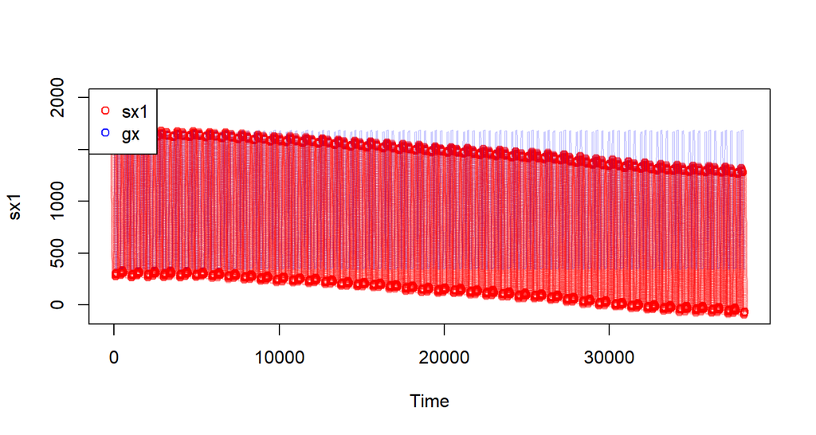

- Looks like a linear trend !

## Simple detrend

- There is a linear trend. \(\mu_t\) in model.

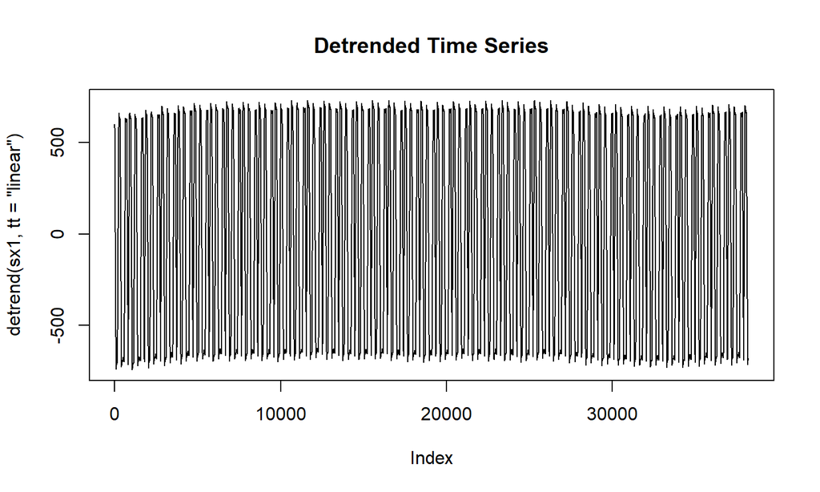

```r
library(pracma)
plot(detrend(sx1, tt = 'linear'),type="l", main = 'Detrended Time Series')
```

## Decompose the time series

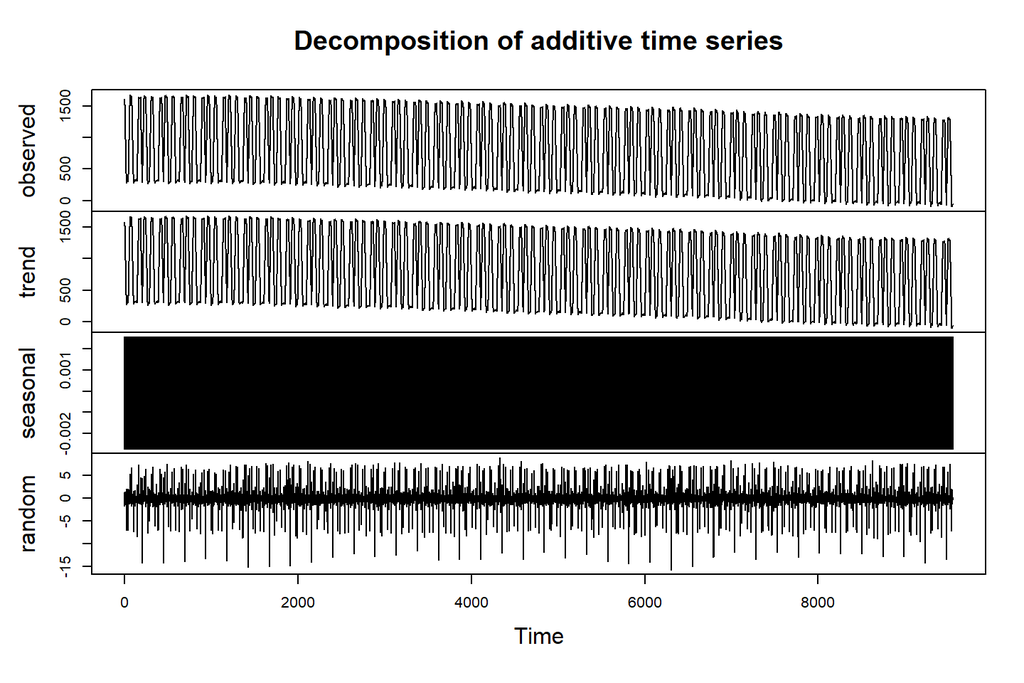

## Local Linear Trend Model

```r
library(dlm)
# Model Construction
buildLinearTrend <- function(psi) dlmModPoly(2, dV = psi[1], dW = psi[2:3], C0 = diag(1e8, 2))
# Model Estimation
mleLinearTrend <- dlmMLE(sx1, parm = c(0.2, 120, 20),build = buildLinearTrend, lower = c(1e-7, 0, 0))
# Checking convergence
mleLinearTrend$conv
```

```
## [1] 52
```

```r
# Estimated variances
(mleLinearTrend$par)
```

```
## [1] 0.0000001 0.0000000 3.9051449
```

```r
# Construct Final Model
linearTrend <- buildLinearTrend(psi = mleLinearTrend$par)
```

## Filtering

- **Filtering**: Estimates of \(\theta_t\) given information available time \(t\).
- ** Smoothing**: Estimates of \(\theta_t\) given information available time \(T\).
- `dlmFilter` for filtering.
- `dlmSmooth` for smoothing.

```r
library(dlm)
lin.f <- dlmFilter(y = sx1, mod = linearTrend)
class(lin.f)
```

```
## [1] "dlmFiltered"
```

## dlmFilter

```r
names(lin.f)
```

```
## [1] "y"   "mod" "m"   "U.C" "D.C" "a"   "U.R" "D.R" "f"
```

- `dlmFilter` returns
1. the series of filtering means \(m_t = E(\theta_t \mid y_t)\),
2. the series of filtering variances \(C_t = Var(\theta_t \mid y_t)\),
3. the series of one-step forecasts for the state \(a_t = E(\theta_t \mid y_{t-1})\),
4. the series of one-step forecast variances for the state \(R_t = Var(\theta_t \mid y_{t-1})\) and
5. the series of one-step forecasts for the observation \(f_t = E(y_t \mid y_{t-1})\).

## Smooting

- dlmSmooth returns:
1. the series of smoothing means \(s_t=E(\theta_t \mid y_T)\).
2. the series of smoothing variances \(S_t=Var(\theta_t \mid y_T)\) : includes t=0.

```r
# Optimal estimates of theta_t given information available at time T.
lin.s <- dlmSmooth(lin.f)
names(lin.s)
```

```
## [1] "s"   "U.S" "D.S"
```

## Plot \(f_t\) and \(s_t\)

Plot filtered \(f_t = E(y_t \mid y_{t-1})\) and smoothing means \(s_t=E(\theta_t \mid y_T)\).

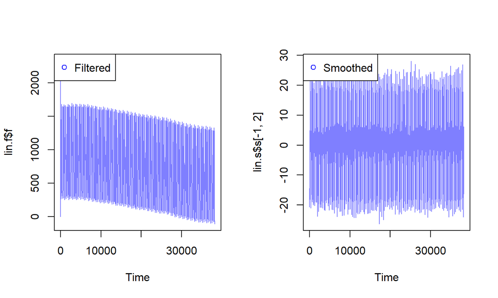

## y-position?

```r
mleLinearTrend <- dlmMLE(sy1, parm = c(0.2, 120, 20),build = buildLinearTrend, lower = c(1e-7, 0, 0))
# Checking convergence
mleLinearTrend$conv
```

```
## [1] 0
```

```r
# Estimated variances
(mleLinearTrend$par)
```

```
## [1] 0.0000001 0.0000000 5.2910272
```

```r
# Construct Final Model
linearTrend <- buildLinearTrend(psi = mleLinearTrend$par)
lin.f2 <- dlmFilter(y = sy1, mod = linearTrend)
lin.s2 <- dlmSmooth(lin.f2)
```

## Plot filtered and smoothed series for y

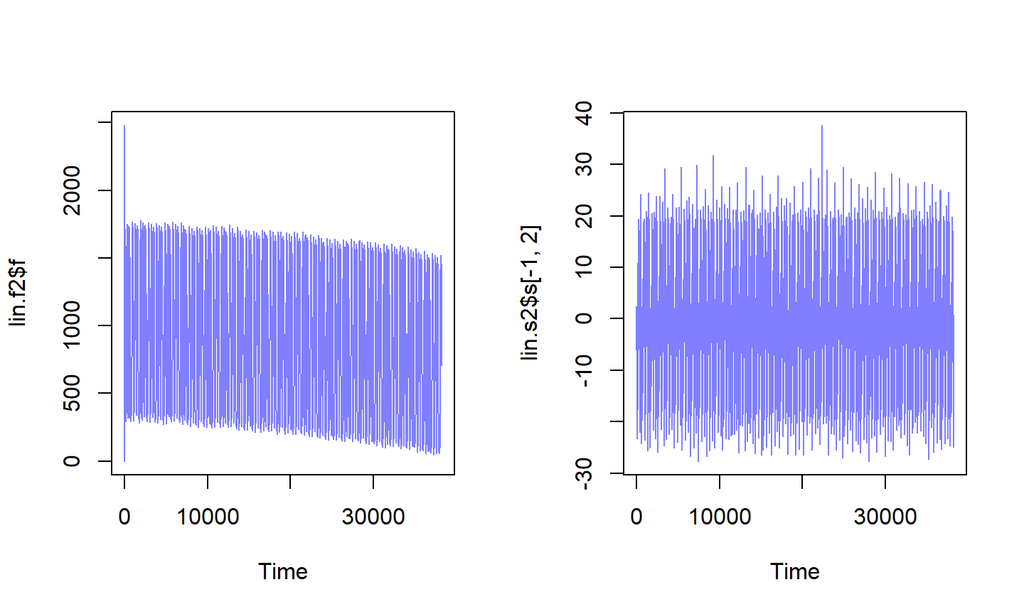

```r
par(mfrow=c(1,2))
plot(Time,lin.f2$f,type="l", col=rgb(0,0,1,0.5))
plot(Time,lin.s2$s[-1,2],type="l", col=rgb(0,0,1,0.5))
```